# Binomial Distribution

Rodrigue Irampa

2024-10-29

Simulate random values that give a binomial Distribution. This represents 10 trials, 30 times, recording only successes. The output is a count how often each number of successes occurred.

*Result Interpretation* Using a binomial distribution with the parameters p=0.5 (probability of success) and N=10 (number of trials), this code creates a random sample of size 30. The frequency of each number of successes in the sample is then printed.

```r
sample_size = 30
p = 0.5
N = 10
dat_1 = rbinom(sample_size, prob = p, size = N)
print("The count how often each number of successes occurred is ")
```

```
## [1] "The count how often each number of successes occurred is "
```

```r
table(dat_1)
```

```
## dat_1
## 2 3 4 5 6 7 8 9
## 2 3 7 9 4 2 2 1
```

## visualization

we have to transform it to a factor to use *Result interpretation* This code produces a bar plot that displays the frequency of each success count after converting dat_1 into a factor with levels 0 to 10. The frequency of each count is displayed on the y-axis, while the x-axis displays the total number of successes.

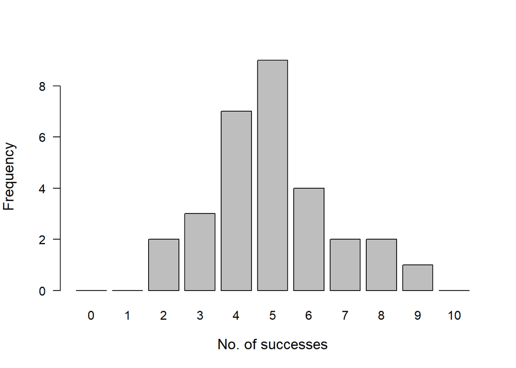

```r
dat1_fac <- factor(dat_1, levels = 0:N)
par(las = 1, cex.lab = 1.2)
barplot(table(dat1_fac), xlab = "No. of successes", ylab = "Frequency")
```

## constructing the Binomial Distribution

```r
p <- 0.5
N <- 10
binom1 <- dbinom(x = 0:10, prob = p, size = N)
sum(binom1)
```

```
## [1] 1
```

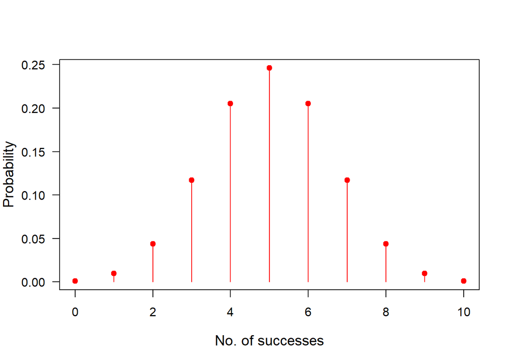

```r
par(las = 1, cex.lab = 1.2)
plot(x = 0:10, y = binom1, type = "h", col = "red", xlab = "No. of successes",
     ylab = "Probability")
points(x = 0:10, y = binom1, col = "red", pch = 19)
```

##. varying probabilities of success

when its at 0.2, its positively skewed, at 0.9 its negatively skewed, at 0.5 its normally distributed. i.e varying P afftects the skewness

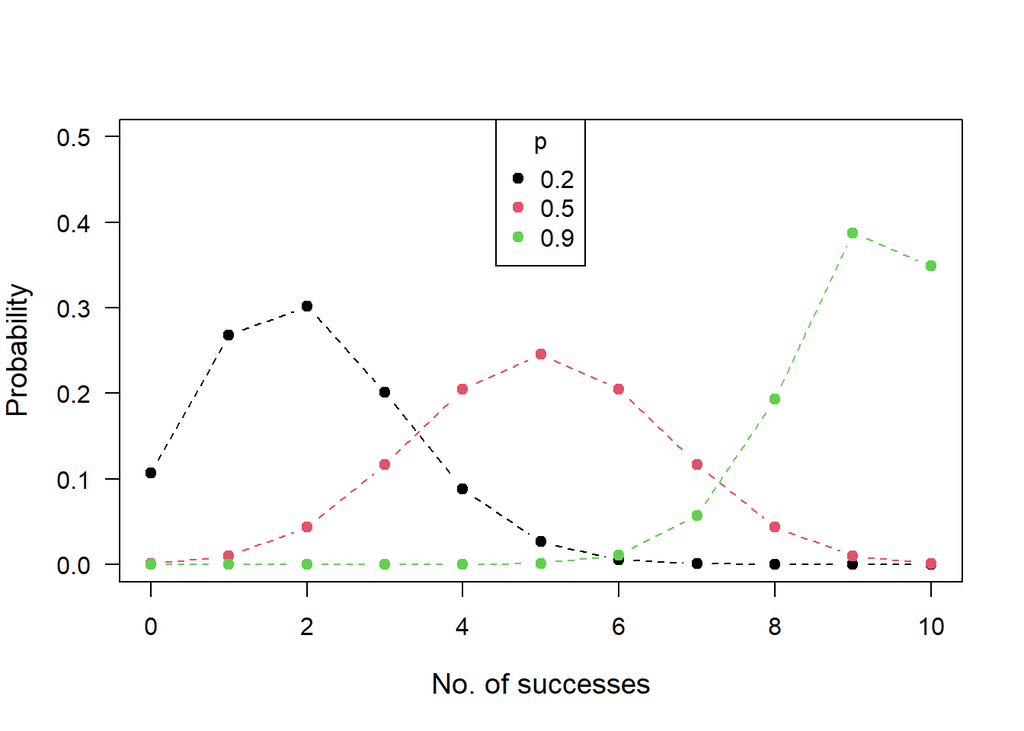

```r
N <- 10
p_vec <- c(0.2, 0.5, 0.9)

x <- 0:N
par(las = 1, cex.lab = 1.2)
plot(x, y = dbinom(x, prob = p_vec[1], size = N), type = "n",
     xlab = "No. of successes", ylab = "Probability", ylim = c(0, 0.5))
for (i in 1:length(p_vec)){
   points(x, y = dbinom(x, prob = p_vec[i], size = N), col = i, type = "b",
          pch = 19, lty = 2)
}
legend("top", legend = p_vec, col = 1:3, pch = 19, title = "p")
```

## Varying N

varying N affects the kurtosis

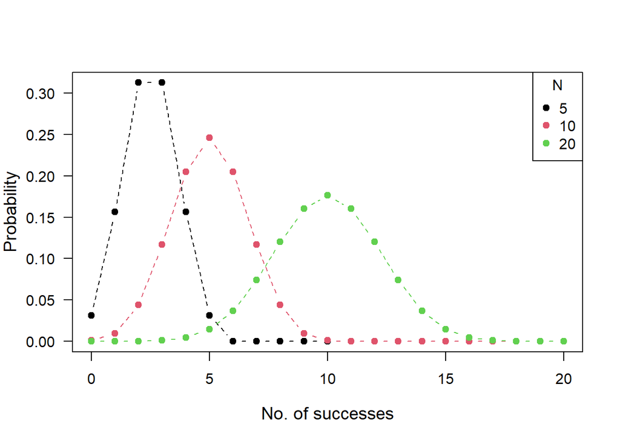

```r
N_vec <- c(5, 10, 20)
p <- 0.5

x <- 0:20
par(las = 1, cex.lab = 1.2)
plot(x, y = dbinom(x, prob = p, size = N_vec[1]), type = "n",
     xlab = "No. of successes", ylab = "Probability")
for (i in 1:length(N_vec)){
   points(x, y = dbinom(x, prob = p, size = N_vec[i]), col = i, type = "b",
          pch = 19, lty = 2)
}
legend("topright", legend = N_vec, col = 1:3, pch = 19, title = "N")
```

## Defining the log-likelihood function

To be able to calculate the likelihood for any parameter values, we define a function for the log-likelihood with the parameters and the data as arguments.

```r
log_likelihood <- function(par_p, par_N, data)
{
   LL <- sum(dbinom(x = data, prob = par_p, size = par_N, log = T))
   return(LL)
}

log_likelihood(par_p = 0.5, par_N = 10, data = dat_1)
```

```
## [1] -57.89442
```

## Maximum Likelihood Estimation

This means we would like to find the parameter, that most likely generated the data. Let us first visualize the data with models of different parameter values.

For this purpose the observed frequencies in the data are converted to proportions by dividing by the sample size.

This is to help standardize frequencies to the same scale as probabilities.

Note; frequencies sum up to the sample size (because we divided my the sample size) ; and proportions sum up to 1

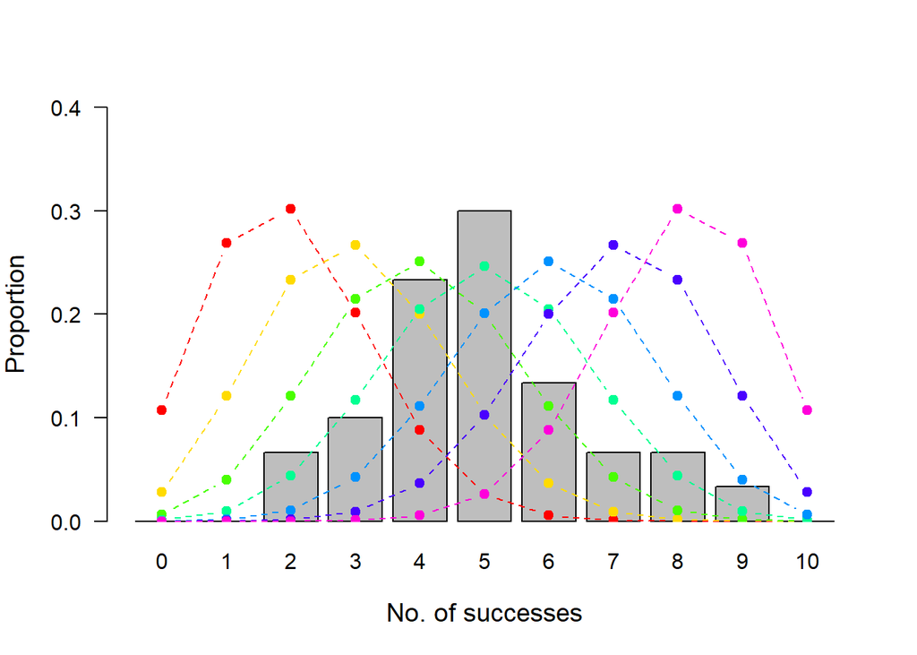

```r
par(las = 1, cex.lab = 1.2)
prop_dat <- table(dat1_fac)/sample_size
xbars <- barplot(prop_dat, xlab = "No. of successes",
                 ylab = "Proportion", ylim = c(0, 0.4))

p_vec <- seq(0.2, 0.8, by = 0.1)
col_vec <- rainbow(length(p_vec))
N <- 10
x <- 0:10
for (i in 1:length(p_vec))
   points(xbars, dbinom(x, prob = p_vec[i], size = N), type = "b", col = col_vec[i], lty = 2,
          pch = 19)
```

To derive the maximum likelihood estimate of p, we evaluate the likelihood function for a sequence of parameter values using a small step size. note; the maximum of the log-likelihood is identical to the maximum of the likelihood *Result interpretation:* This code uses the binomial distribution with N = 10 trials, data from dat_1, and a step size of 0.01 to compute the log-likelihood for various values of p ranging from 0 to 1. The log-likelihood is then plotted versus p, and a red point and line are used to indicate the p value that maximizes the log-likelihood (MLE).

```r
p_vec <- seq(0, 1, by = 0.01)
logLik <- sapply(p_vec, FUN = log_likelihood, par_N = 10, data = dat_1)

par(las = 1, cex.lab = 1.2)
plot(p_vec, logLik, type = "l", xlab = "p", ylab = "log-Likelihood")

imax <- which.max(logLik)
p_MLE <- p_vec[imax]
p_MLE
```

```
## [1] 0.5
```

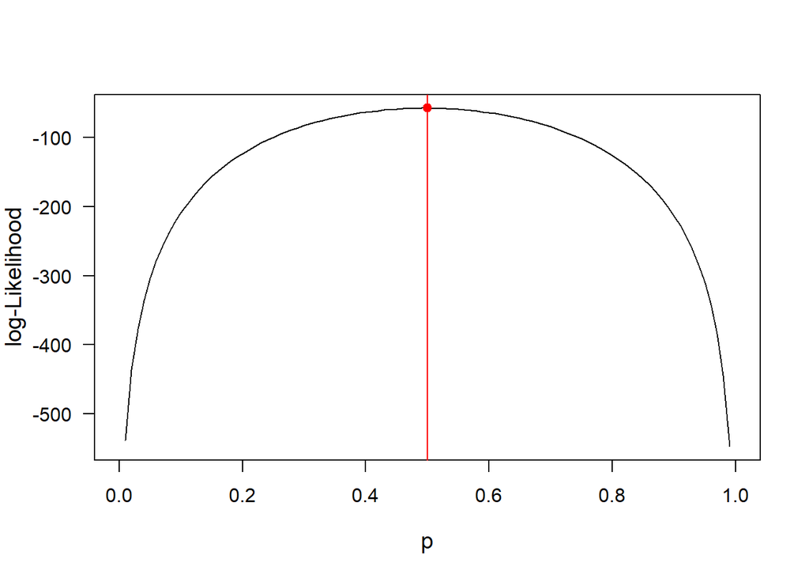

```r
points(p_MLE, max(logLik), pch = 19, col = "red")
abline(v = p_MLE, col = "red")
```

The maximum likelihood estimate is close to the true value used for the data generation. It follows that, the larger the sample size, the lower this difference will be.

## The true value

we can now estimate to the true value with increasing sample size. we plot the data with the theoretical underlying distribution as well as with the distribution based on the MLE estimate *Result interpretation:* The percentage of each success count in the prop_dat data is displayed in a bar plot created by this code. Next, using the previously determined MLE estimate (p_MLE) and true probability (p = 0.5), it overlays the theoretical binomial probabilities for success counts. The legend uses various colors and point styles to show the data, the true probability, and the MLE probability.

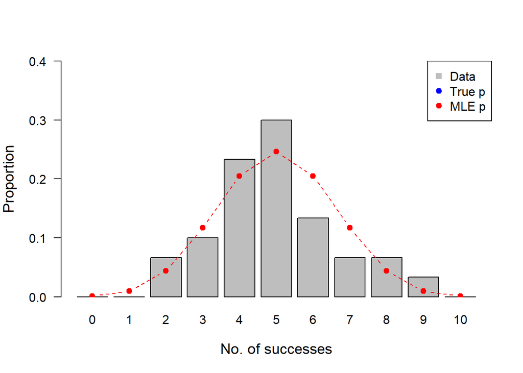

```r
par(las = 1, cex.lab = 1.2)
xbars <- barplot(prop_dat, xlab = "No. of successes",
                 ylab = "Proportion", ylim = c(0, 0.4))
points(xbars, dbinom(x, prob = 0.5, size = 10), type = "b", col = "blue",
       pch = 19, lty = 2)
points(xbars, dbinom(x, prob = p_MLE, size = 10), type = "b", col = "red",
       pch = 19, lty = 2)
legend("topright", legend = c("Data","True p","MLE p"),
       col = c("gray", "blue","red"), pch = c(15, 19, 19))
```